# Practical 3 Exploratory Data Analysis

Supervised Learning & Visualization

Ernst Paul Swens

October, 2022

# Q1

**Create a histogram of the variable age using the function `geom_histogram()`.**

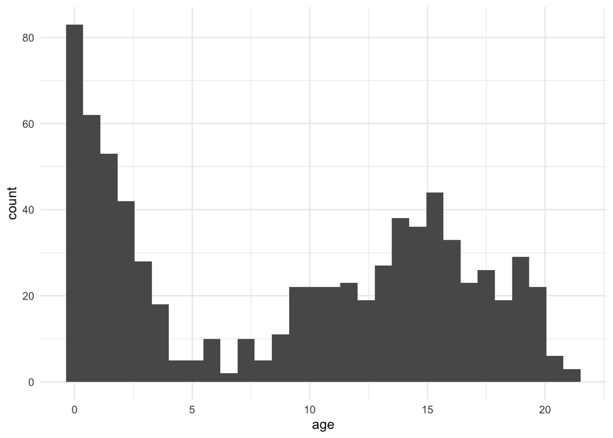

```r
ggplot(boys, aes(x = age)) +
   geom_histogram(bins = 30) +
   theme_minimal()
```

# Q2

**Create a bar chart of the variable gen using the function `geom_bar()`**

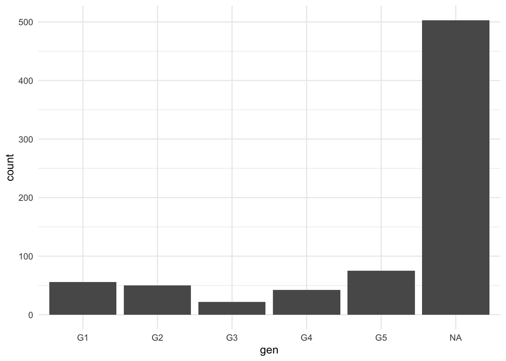

```r
ggplot(boys, aes(x = gen)) +
   geom_bar() +
   theme_minimal()
```

# Q3

**Create a missingness indicator for the variables `gen`, `phb` and `tv`.**

```r
boys.2 <- boys %>%
   mutate(
      rgen = as.factor(ifelse(is.na(gen), 1, 0)),
      rphb = as.factor(ifelse(is.na(phb), 1, 0)),
      rtv = as.factor(ifelse(is.na(tv), 1, 0))
   )
```

# Q4

**Assess whether missingness in the variables `gen`, `phb` and `tv` is related to someones `age`.**

```r
boys.2 %>%
   summarise(
      gen = cor(as.numeric(rgen), age),
      phb = cor(as.numeric(rphb), age),
      tv = cor(as.numeric(rtv), age)
   )
```

```
##          gen        phb         tv
## 1 -0.4933847 -0.4930341 -0.4707914
```

# Q5

**Create a histogram for the variable `age`, faceted by whether or not someone has a missing value on gen.**

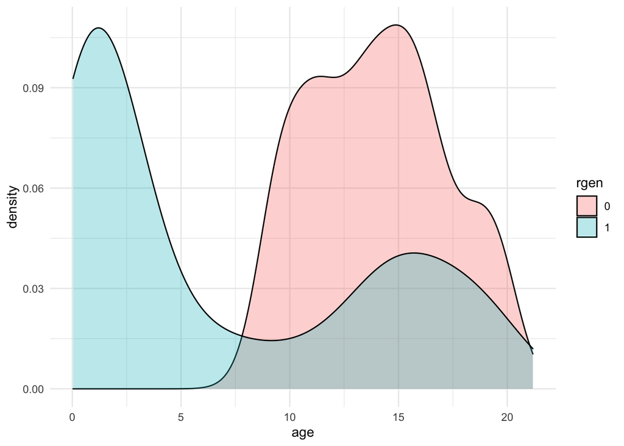

```r
ggplot(boys.2, aes(x = age, fill = rgen)) +
   geom_density(alpha = 0.3) +
   theme_minimal()
```

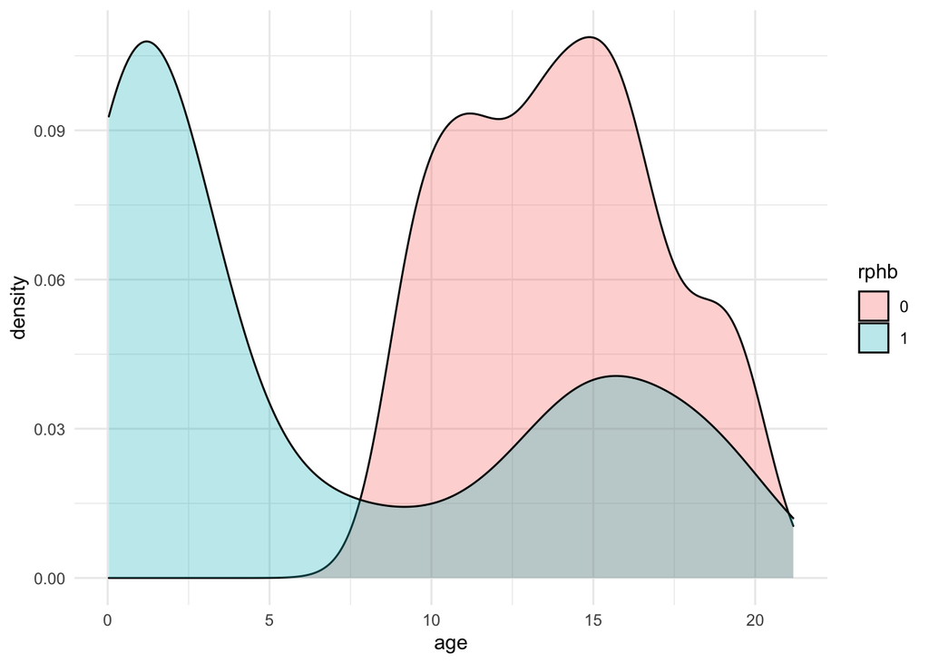

```r
ggplot(boys.2, aes(x = age, fill = rphb)) +
   geom_density(alpha = 0.3) +
   theme_minimal()
```

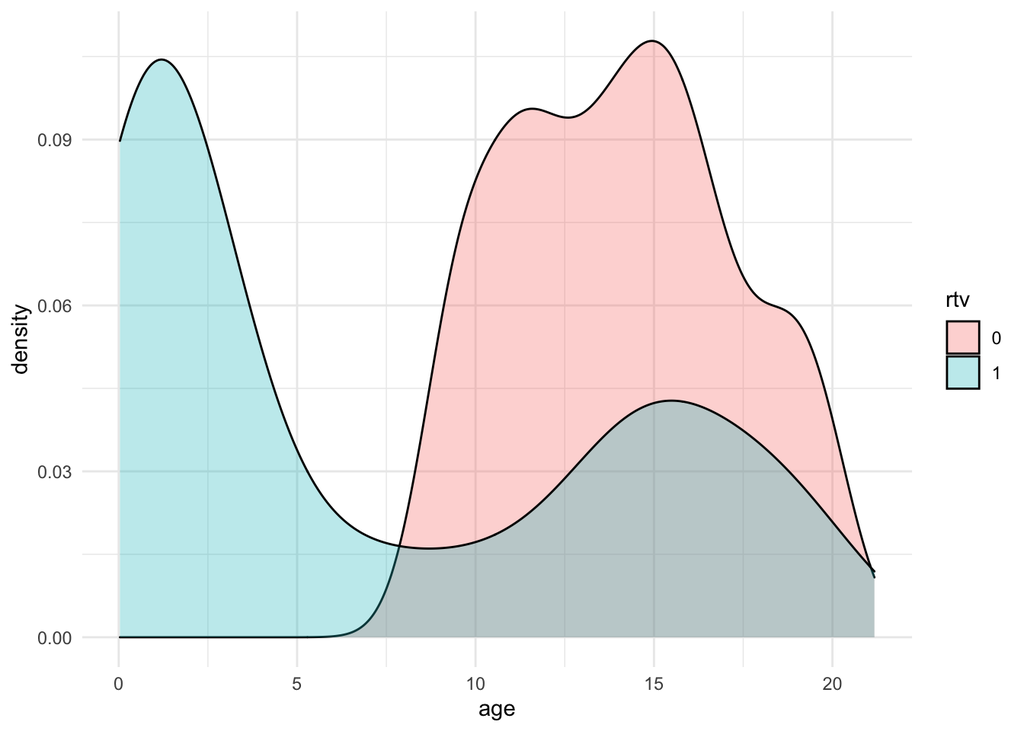

```r
ggplot(boys.2, aes(x = age, fill = rtv)) +
   geom_density(alpha = 0.3) +
   theme_minimal()
```

# Q6

**Create a scatterplot with age on the x-axis and bmi on the y-axis, using the function `geom_point()`.**

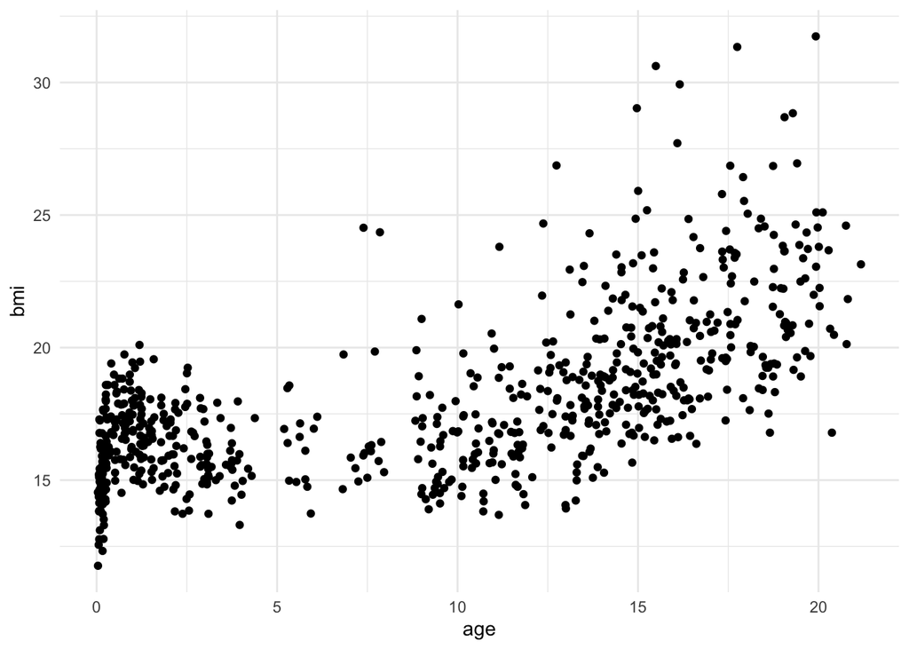

```r
boys.2 %>% ggplot(aes(x = age, y = bmi)) +
   geom_point() +
   theme_minimal()
```

# Q7

**Add a colour aesthetic to the previous plot using the missingness indicator of the variable gen.**

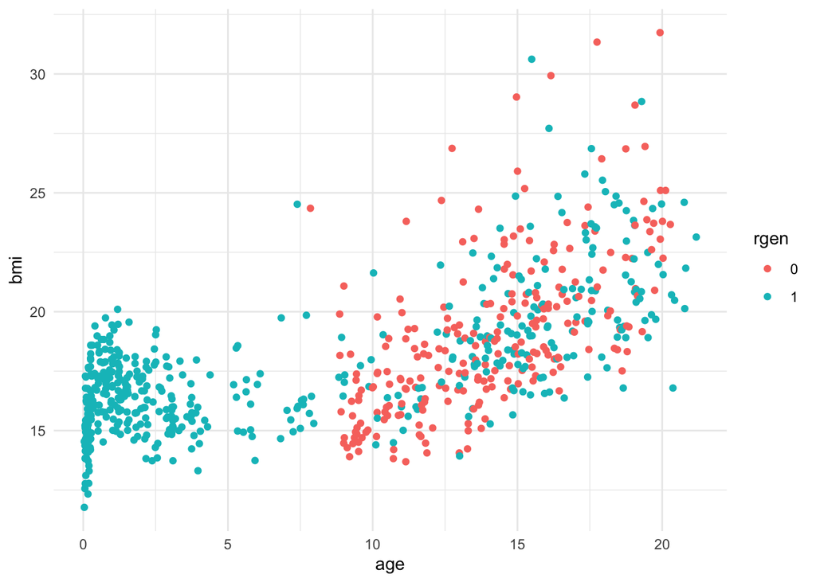

```r
boys.2 %>% ggplot(aes(x = age, y = bmi, color = rgen)) +
   geom_point() +
   theme_minimal()
```

# Q8

**Visualize the relationship between reg (region) and age using a boxplot.**

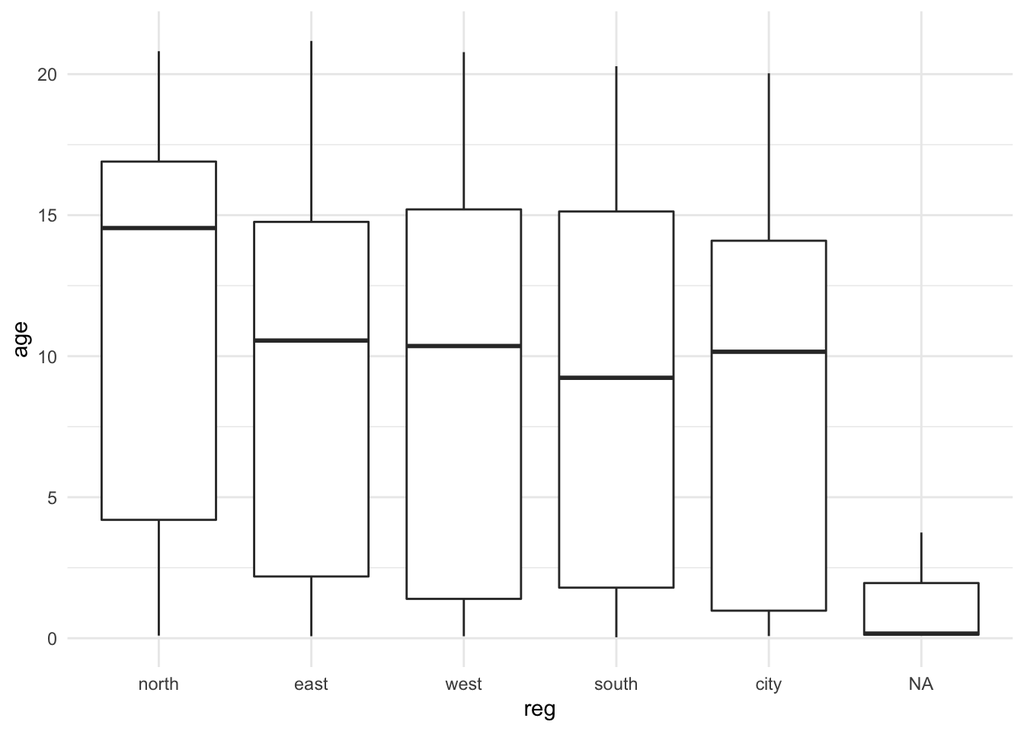

```r
boys.2 %>% ggplot(aes(x = reg, y = age)) +
   geom_boxplot() +
   theme_minimal()
```

# Q9

**Create a density plot of age, splitting the densities by gen using the fill aesthetic.**

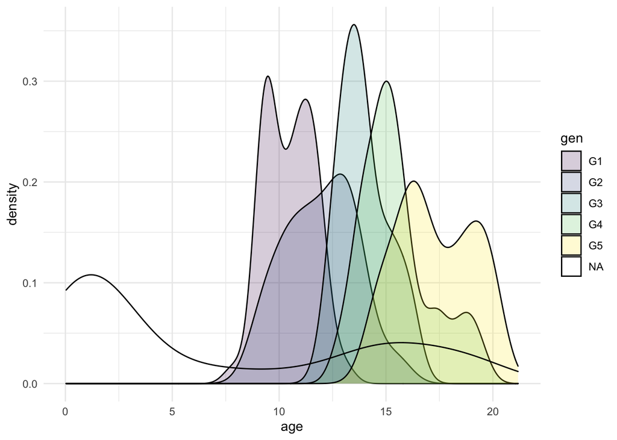

```r
boys.2 %>% ggplot(aes(x = age, fill = gen)) +
   geom_density(alpha = 0.2) +
   theme_minimal()
```

# Q10

**Create a diverging bar chart for hgt in the boys data set, that displays for every age year that year’s mean height in deviations from the overall average hgt.**

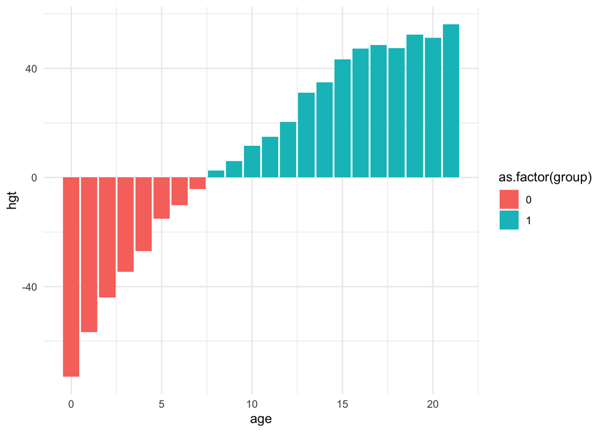

```r
boys.2 %>% mutate(age = round(age),
                  hgt = hgt - mean(boys.2$hgt, na.rm = TRUE)) %>%
   group_by(age) %>%
   summarise(hgt = mean(hgt, na.rm = TRUE)) %>%
   mutate(group = ifelse(hgt < 1, 0, 1)) %>%
   ggplot(aes(x = age, y = hgt, fill = as.factor(group))) +
   geom_bar(stat = "identity") +
   theme_minimal()
```

# Q11

**Load the data elastic1 and elastic2 and bind the data frames together using the function bind_rows() and add a grouping variable indicating whether an observation comes from elastic1 or from elastic2.**

```r
elastic <- bind_rows(
   "Elastic1" = elastic1,
   "Elastic2" = elastic2,
   .id = "Set"
)
```

# Q12

**Create a scatterplot mapping stretch on the x-axis and distance on the y-axis, and map the just created group indicator as the color aesthetic.**

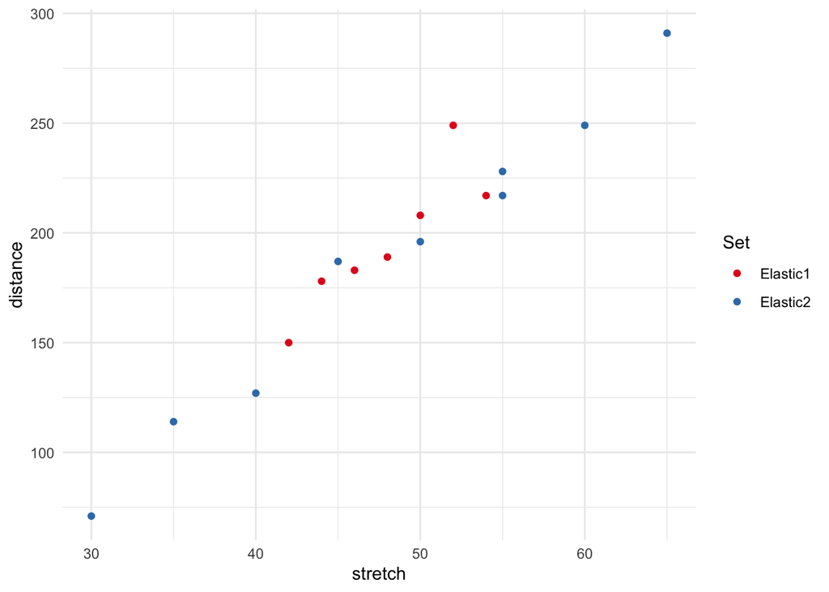

```r
elastic %>%
  ggplot(aes(x = stretch, y = distance, col = Set)) +
  geom_point() +
  scale_color_brewer(palette = "Set1") +
  theme_minimal()
```

# Q13

**Recreate the previous plot, but now assess whether the results of the two data sets appear consistent by adding a linear regression line.**

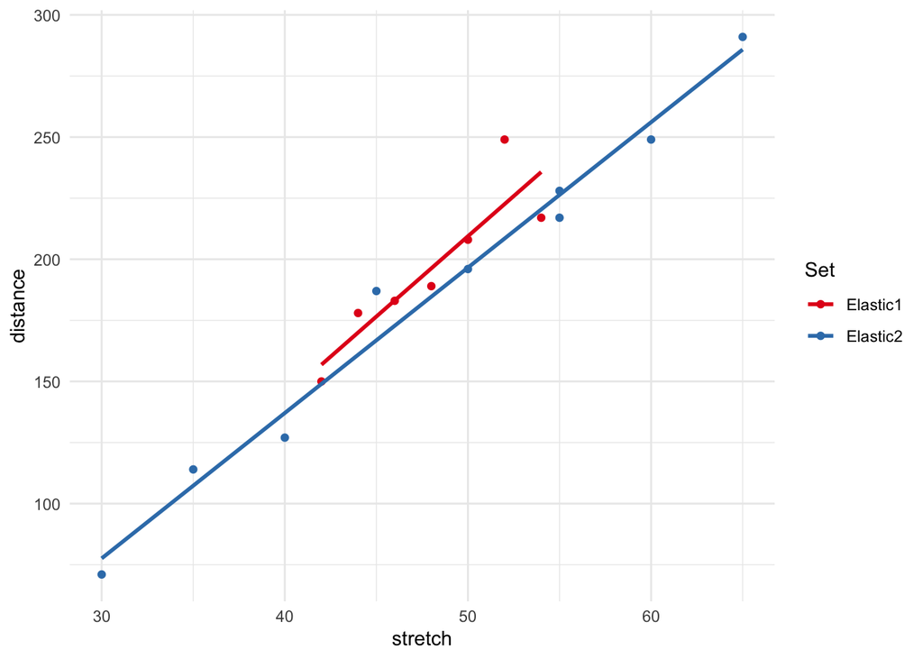

```r
elastic %>%
   ggplot(aes(x = stretch, y = distance, col = Set)) +
   geom_point() +
   geom_smooth(method = "lm", se = FALSE) +
   scale_color_brewer(palette = "Set1") +
   theme_minimal()
```

# Q14

**For each of the data sets `elastic1` and `elastic2`, fit a regression model with y = distance on x = stretch using `lm(y ~ x, data)`.**

```r
lm.1 <- lm(distance ~ stretch, elastic1)
lm.2 <- lm(distance ~ stretch, elastic2)
```

# Q15

**For both of the previously created fitted models, determine the fitted values and the standard errors of the fitted values, and the proportion explained variance $R^2$.**

```r
predict(lm.1, se.fit = TRUE)
```

```
## $fit
##        1        2        3        4        5        6        7
## 183.1429 235.7143 196.2857 209.4286 170.0000 156.8571 222.5714
##
## $se.fit
## [1]  6.586938 10.621119  5.891537  6.586938  8.331891 10.621119  8.331891
##
## $df
## [1] 5
##
## $residual.scale
## [1] 15.58754
```

```r
predict(lm.2, se.fit = TRUE)
```

```
## $fit
##         1         2         3         4         5         6         7         8
##  77.58333 196.58333 137.08333 166.83333 256.08333 226.33333 107.33333 226.33333
##         9
## 285.83333
##
## $se.fit
## [1] 6.740293 3.520003 4.358744 3.635444 5.060323 4.064550 5.453165 4.064550
## [9] 6.296773
##
## $df
## [1] 7
##
## $residual.scale
## [1] 10.44202
```

```r
lm.1 %>% summary() %$% r.squared
```

```
## [1] 0.7992446
```

```r
lm.2 %>% summary() %$% r.squared
```

```
## [1] 0.9807775
```

# Q16

**Study the residual versus leverage plots for both models.**

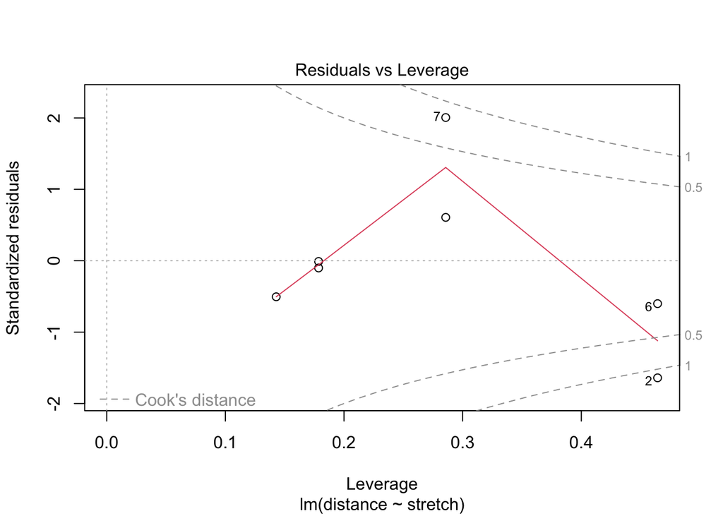

```r
plot(lm.1, which = 5)
```

```r
lm.1$residuals
```

```
##           1           2           3           4           5           6
##  -0.1428571 -18.7142857  -7.2857143  -1.4285714   8.0000000  -6.8571429
##           7
##  26.4285714
```

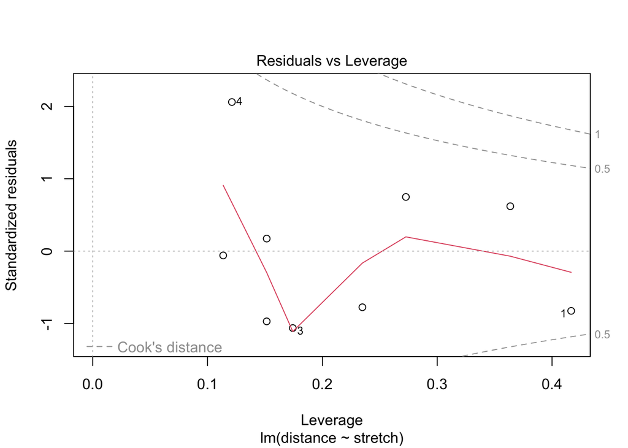

```r
plot(lm.2, which = 5)
```

```r
lm.2$residuals
```

```
##           1           2           3           4           5           6
##  -6.5833333  -0.5833333 -10.0833333  20.1666667  -7.0833333  -9.3333333
##           7           8           9
##   6.6666667   1.6666667   5.1666667
```

# Q17

**Use the `elastic2` variable stretch to obtain predictions on the model fitted on `elastic1`.**

```r
pred <- predict(lm.1, newdata = elastic2)
```

# Q18

**# 18. Now make a scatterplot to investigate similarity between the predicted values and the observed values for `elastic2`.**

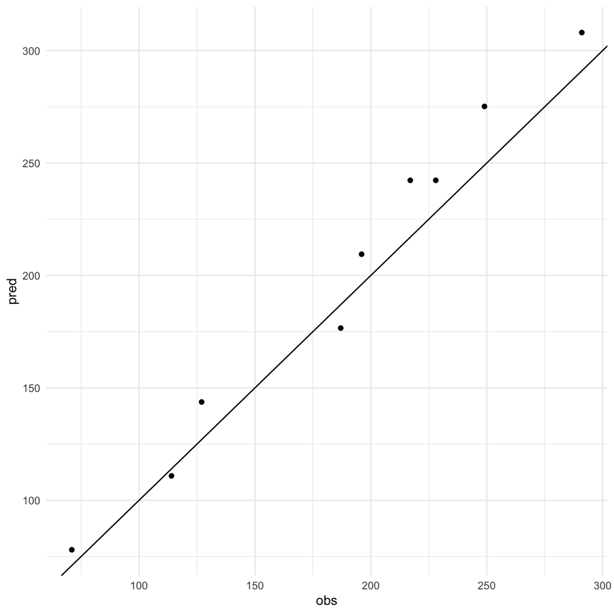

```r
data.frame(pred = pred,
           obs = elastic2$distance) %>%
   ggplot(aes(x = obs, y = pred)) +
   geom_point() +
   geom_abline(intercept = 0, slope = 1) +
   theme_minimal()
```